# Lysates_metabar_for_PLOSone_LabProtocols

2022-11-29

This data come from the “15 samples” experiment

## Data formating

### Load raw data and remove 0’s

### Number of reads per sample: minimum, maximum, average:

```r
min(colSums(tab_no0))
```

```
## [1] 368060
```

```r
max(colSums(tab_no0))
```

```
## [1] 1299458
```

```r
mean(colSums(tab_no0))
```

```
## [1] 713133.4
```

### Getting taxonomy file

Export ASV list to a separate file and get taxonomy assignement file for those ASVs

## Summary stats

### Total number of ASVs:

```r
length(rownames(tab_no0))
```

```
## [1] 1046
```

### Wet weight of a sample (proxy for biomass) and the number of reads per sample:

– *Samples sorted by habitat and by sampling date (increasing) –* Wet-weight shown as white diamonds

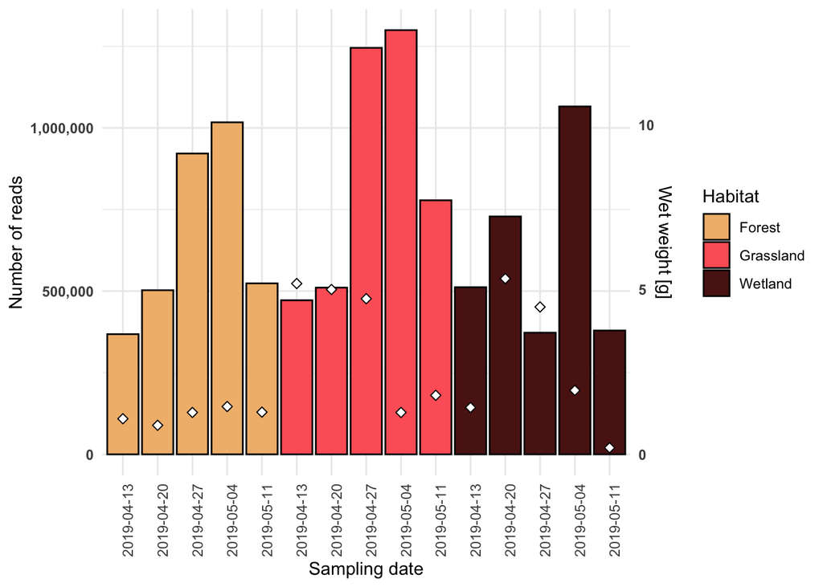

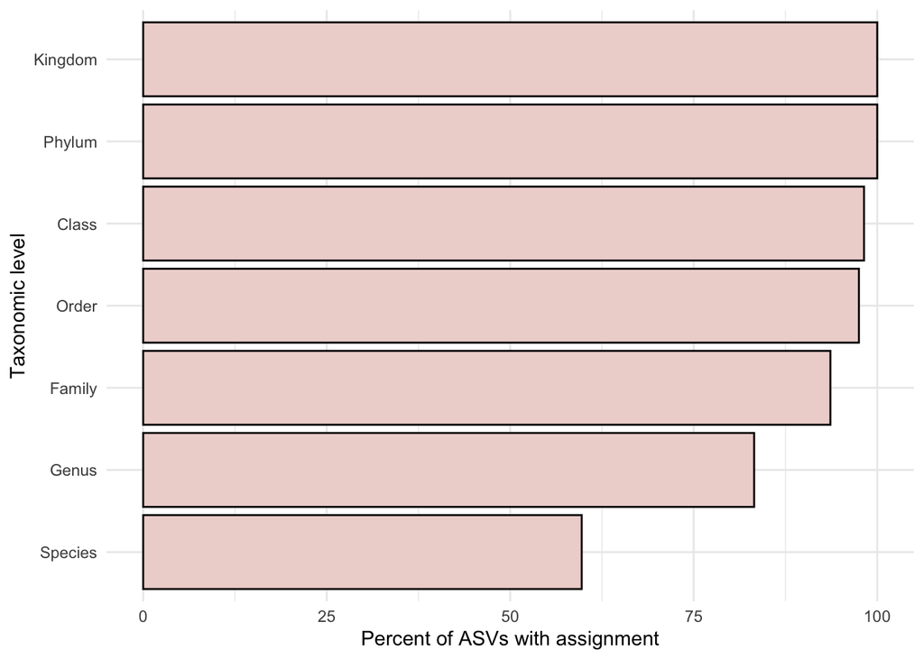

## ASVs shared between habitats

### Venn diagram showing numbers of shared and habitat-unique ASVs

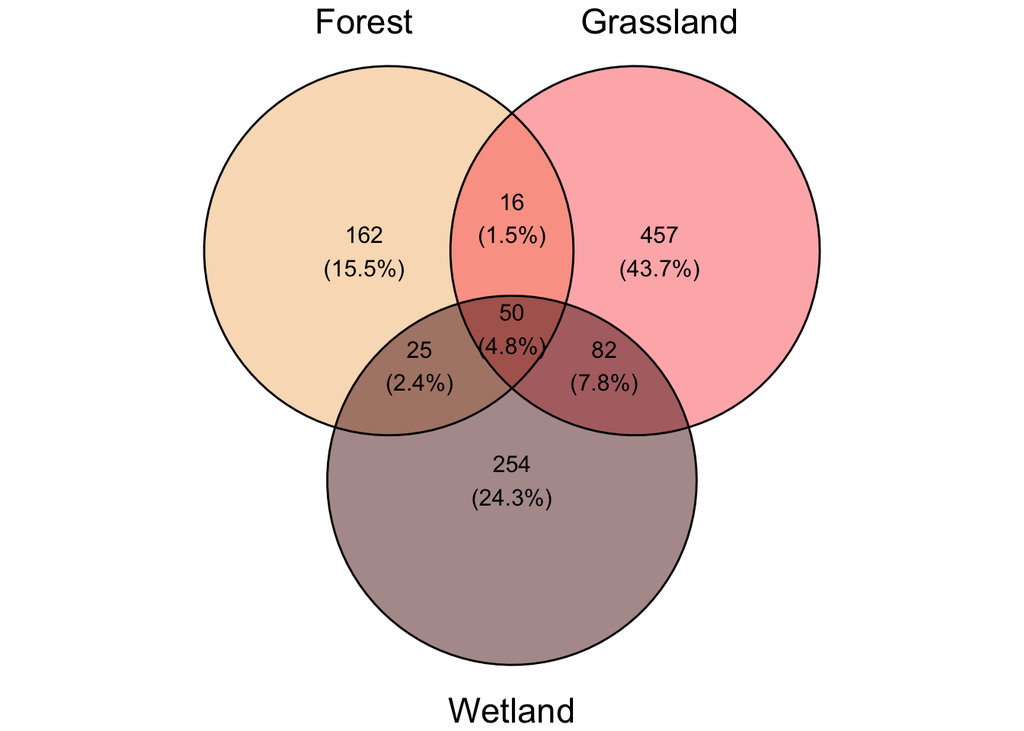

### Getting a list of ASVs shared between all habitats (Should be 50 ASVs)

## Ordination

### Calculating a non-metric multidimensional scaling (nMDS)

### Stress factor

```
## [1] 0.08362404
```

As a rule of thumb literature has identified the following cut-off values for stress-level:

Higher than 0.2 is poor (risks for false interpretation). 0.1 - 0.2 is fair (some distances can be misleading for interpretation). 0.05 - 0.1 is good (can be confident in inferences from plot). Less than 0.05 is excellent (this can be rare).

### Plotting nMDS

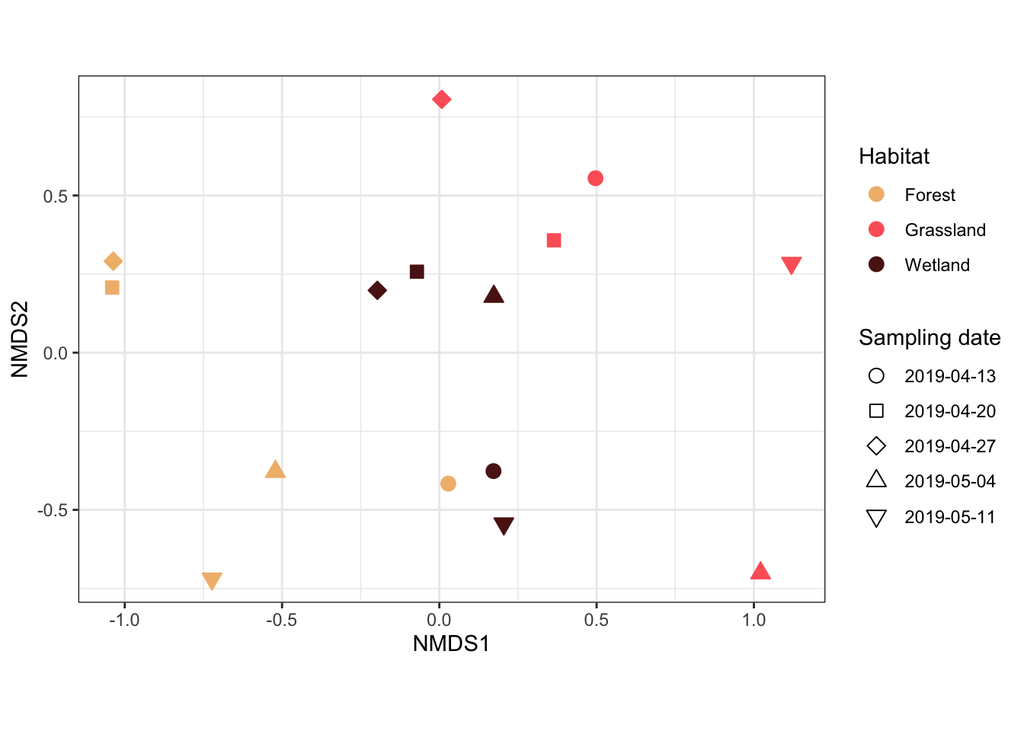

### ASVs grouped per order

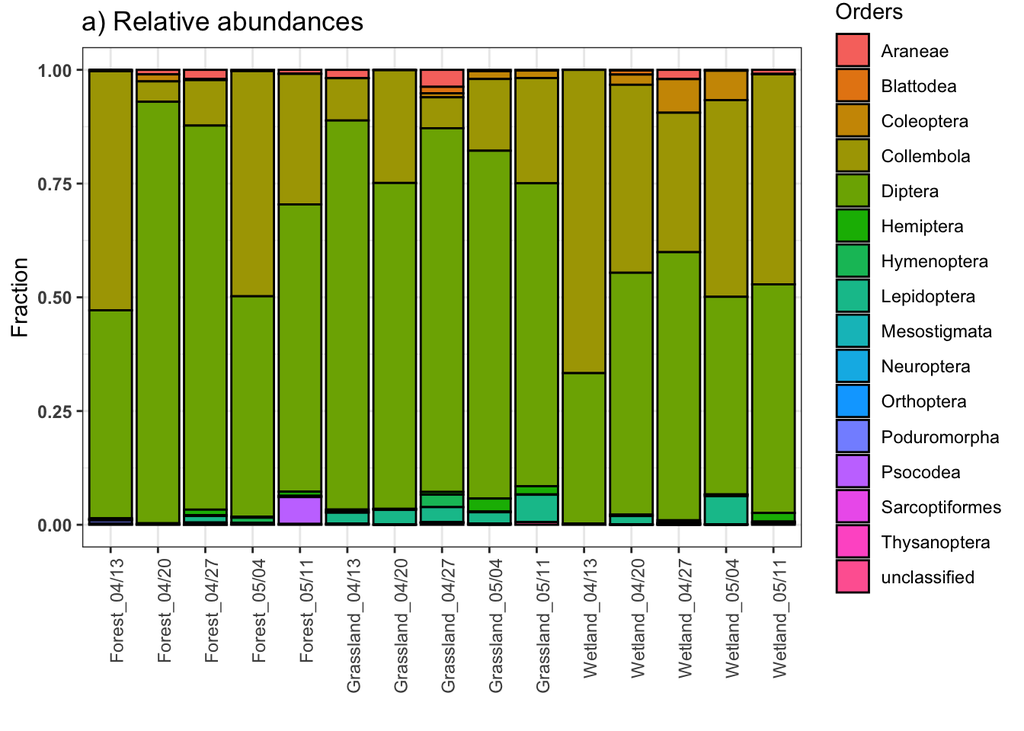

## Read abundance per sample = Wet-weight corrected

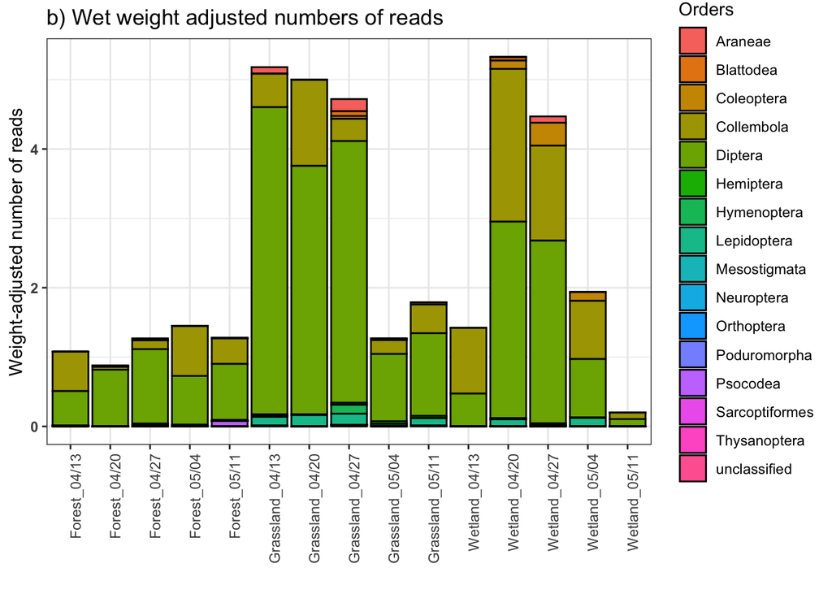

### Number of reads per sample - spike-in corrected

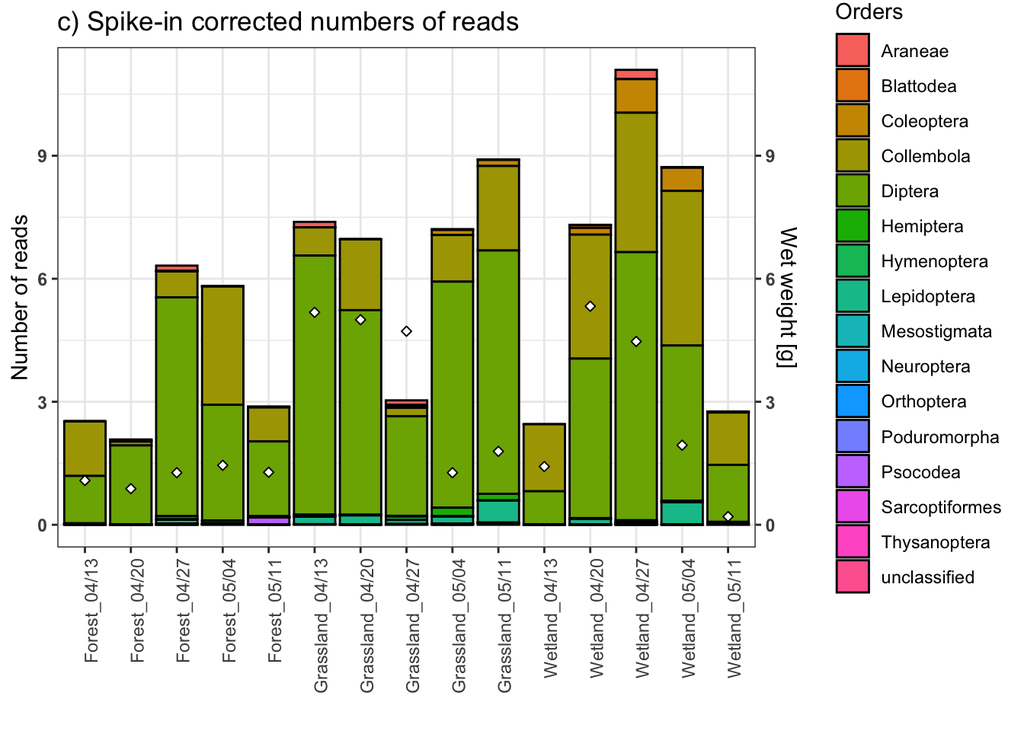

## Ordination on raw ASV data excluding spike-ins

### Calculating a non-metric multidimensional scaling (nMDS)

### Stress factor

```
## [1] 0.08661942
```

As a rule of thumb literature has identified the following cut-off values for stress-level:

Higher than 0.2 is poor (risks for false interpretation). 0.1 - 0.2 is fair (some distances can be misleading for interpretation). 0.05 - 0.1 is good (can be confident in inferences from plot). Less than 0.05 is excellent (this can be rare).

### Plotting nMDS without spike-ins

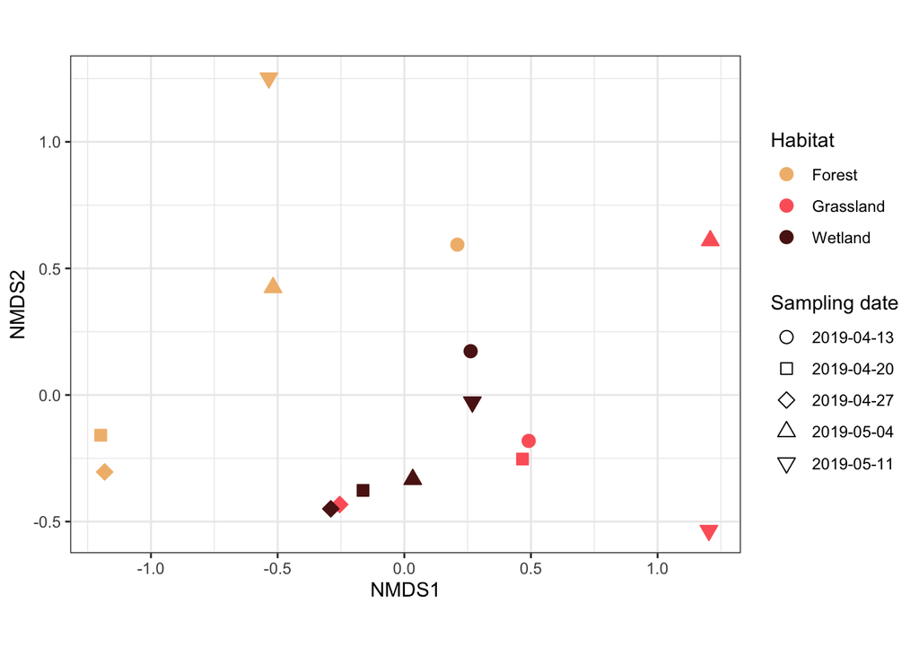